# Исследование объявлений о продаже квартир

#### Обработка пропусков в высоте потолка

```python
ceiling_height_grouped = data.pivot_table(index='floors_total',values=['ceiling_height'],aggfunc=['mean'])
ceiling_height_grouped.head()
```

| floors_total | mean ceiling_height |
| --- | --- |
| 1.0 | 2.740000 |
| 2.0 | 3.006791 |
| 3.0 | 2.969474 |
| 4.0 | 2.986831 |
| 5.0 | 2.793191 |

```python
ceiling_height_grouped.columns = ['mean_ceil_val']
```

```python
#функция которая заполняемт высоту потолка в зависимости от того,сколько этажей в доме
def setting_ceiling_height(row,ceiling_height_grouped=ceiling_height_grouped):
    floors_total = row['floors_total']
    ceiling_height = row['ceiling_height']

    if pd.isna(ceiling_height) or pd.isnull(ceiling_height):
        try:
            row['ceiling_height'] = ceiling_height_grouped[ceiling_height_grouped.index == floors_total]['mean_ceil_val'][floors_total]
        except KeyError:
            pass
    return row
```

```python
data = data.apply(setting_ceiling_height,axis=1)
```

```python
data.head()
```

|  | total_images | last_price | total_area | first_day_exposition | rooms | ceiling_height | floors_total | living_area | floor | is_apartment | ... | kitchen_area | balcony | locality_name | airports_nearest | cityCenters_nearest | parks_around3000 | parks_nearest | ponds_around3000 | ponds_nearest | days_exposition |
| --- | --- | --- | --- | --- | --- | --- | --- | --- | --- | --- | --- | --- | --- | --- | --- | --- | --- | --- | --- | --- | --- |
| 0 | 20 | 13000000.0 | 108.0 | 2019-03-07T00:00:00 | 3 | 2.700000 | 16.0 | 51.0 | 8 | NaN | ... | 25.0 | NaN | Санкт-Петербург | 18863.0 | 16028.0 | 1.0 | 482.0 | 2.0 | 755.0 | NaN |
| 1 | 7 | 3350000.0 | 40.4 | 2018-12-04T00:00:00 | 1 | 2.782385 | 11.0 | 18.6 | 1 | NaN | ... | 11.0 | 2.0 | посёлок Шушары | 12817.0 | 18603.0 | 0.0 | NaN | 0.0 | NaN | 81.0 |
| 2 | 10 | 5196000.0 | 56.0 | 2015-08-20T00:00:00 | 2 | 2.793191 | 5.0 | 34.3 | 4 | NaN | ... | 8.3 | 0.0 | Санкт-Петербург | 21741.0 | 13933.0 | 1.0 | 90.0 | 2.0 | 574.0 | 558.0 |
| 3 | 0 | 64900000.0 | 159.0 | 2015-07-24T00:00:00 | 3 | 2.731545 | 14.0 | NaN | 9 | NaN | ... | NaN | 0.0 | Санкт-Петербург | 28098.0 | 6800.0 | 2.0 | 84.0 | 3.0 | 234.0 | 424.0 |
| 4 | 2 | 10000000.0 | 100.0 | 2018-06-19T00:00:00 | 2 | 3.030000 | 14.0 | 32.0 | 13 | NaN | ... | 41.0 | NaN | Санкт-Петербург | 31856.0 | 8098.0 | 2.0 | 112.0 | 1.0 | 48.0 | 121.0 |

5 rows × 22 columns

#### Заполнение пропусков данных в жилой площади и площади кухни

```python
#взглянем на корреляционную таблицу
data.corr()
```

|  | total_images | last_price | total_area | rooms | ceiling_height | floors_total | living_area | floor | studio | open_plan | kitchen_area | balcony | airports_nearest | cityCenters_nearest | parks_around3000 | parks_nearest | ponds_around3000 | ponds_nearest | days_exposition |
| --- | --- | --- | --- | --- | --- | --- | --- | --- | --- | --- | --- | --- | --- | --- | --- | --- | --- | --- | --- |
| total_images | 1.000000 | 0.104473 | 0.115352 | 0.099288 | -0.000053 | 0.011120 | 0.104780 | 0.031340 | -0.029303 | -0.024407 | 0.104756 | 0.121693 | -0.002298 | -0.047666 | 0.021120 | -0.008347 | -0.011553 | -0.003034 | -0.026657 |
| last_price | 0.104473 | 1.000000 | 0.653675 | 0.363343 | 0.064741 | -0.007003 | 0.566492 | 0.026576 | -0.025362 | -0.008802 | 0.519869 | 0.029646 | -0.026239 | -0.206747 | 0.151058 | -0.016414 | 0.159996 | -0.084809 | 0.081146 |
| total_area | 0.115352 | 0.653675 | 1.000000 | 0.758344 | 0.083166 | -0.075674 | 0.939537 | -0.024754 | -0.072653 | -0.034885 | 0.609121 | 0.047937 | -0.030753 | -0.231446 | 0.164689 | -0.021497 | 0.162346 | -0.097969 | 0.149675 |
| rooms | 0.099288 | 0.363343 | 0.758344 | 1.000000 | 0.048402 | -0.227649 | 0.845977 | -0.150862 | -0.147286 | -0.087500 | 0.269945 | 0.017991 | -0.061199 | -0.184864 | 0.137257 | -0.054549 | 0.092693 | -0.057689 | 0.126961 |
| ceiling_height | -0.000053 | 0.064741 | 0.083166 | 0.048402 | 1.000000 | -0.034323 | 0.080479 | -0.017288 | 0.000503 | 0.019070 | 0.075154 | 0.028486 | -0.022700 | -0.077943 | 0.061461 | -0.020300 | 0.071755 | -0.052084 | 0.017015 |
| floors_total | 0.011120 | -0.007003 | -0.075674 | -0.227649 | -0.034323 | 1.000000 | -0.169090 | 0.674346 | 0.069103 | 0.050834 | 0.163521 | 0.194936 | 0.107848 | 0.019502 | -0.252265 | 0.096972 | -0.122593 | 0.038994 | -0.052123 |
| living_area | 0.104780 | 0.566492 | 0.939537 | 0.845977 | 0.080479 | -0.169090 | 1.000000 | -0.097210 | -0.056231 | -0.033711 | 0.428674 | 0.018849 | -0.057912 | -0.231368 | 0.184453 | -0.050167 | 0.148933 | -0.081674 | 0.142454 |
| floor | 0.031340 | 0.026576 | -0.024754 | -0.150862 | -0.017288 | 0.674346 | -0.097210 | 1.000000 | 0.036940 | 0.035824 | 0.135531 | 0.168773 | 0.071597 | 0.009084 | -0.163784 | 0.073045 | -0.076312 | 0.024850 | -0.039463 |
| studio | -0.029303 | -0.025362 | -0.072653 | -0.147286 | 0.000503 | 0.069103 | -0.056231 | 0.036940 | 1.000000 | -0.004235 | NaN | 0.031455 | -0.021876 | -0.007029 | -0.030202 | 0.009134 | 0.000939 | 0.002606 | -0.022476 |
| open_plan | -0.024407 | -0.008802 | -0.034885 | -0.087500 | 0.019070 | 0.050834 | -0.033711 | 0.035824 | -0.004235 | 1.000000 | NaN | 0.019491 | -0.013583 | -0.004204 | -0.010077 | 0.010612 | 0.008455 | -0.003328 | -0.024112 |
| kitchen_area | 0.104756 | 0.519869 | 0.609121 | 0.269945 | 0.075154 | 0.163521 | 0.428674 | 0.135531 | NaN | NaN | 1.000000 | 0.098634 | 0.008200 | -0.190049 | 0.087503 | 0.029641 | 0.150148 | -0.105223 | 0.100586 |
| balcony | 0.121693 | 0.029646 | 0.047937 | 0.017991 | 0.028486 | 0.194936 | 0.018849 | 0.168773 | 0.031455 | 0.019491 | 0.098634 | 1.000000 | 0.066834 | 0.051051 | -0.082850 | 0.052328 | -0.032709 | 0.010847 | -0.032909 |
| airports_nearest | -0.002298 | -0.026239 | -0.030753 | -0.061199 | -0.022700 | 0.107848 | -0.057912 | 0.071597 | -0.021876 | -0.013583 | 0.008200 | 0.066834 | 1.000000 | 0.272184 | 0.000759 | -0.070058 | -0.049583 | 0.014049 | -0.018271 |
| cityCenters_nearest | -0.047666 | -0.206747 | -0.231446 | -0.184864 | -0.077943 | 0.019502 | -0.231368 | 0.009084 | -0.007029 | -0.004204 | -0.190049 | 0.051051 | 0.272184 | 1.000000 | -0.161738 | -0.040650 | -0.074577 | 0.028903 | -0.060714 |
| parks_around3000 | 0.021120 | 0.151058 | 0.164689 | 0.137257 | 0.061461 | -0.252265 | 0.184453 | -0.163784 | -0.030202 | -0.010077 | 0.087503 | -0.082850 | 0.000759 | -0.161738 | 1.000000 | -0.259514 | 0.304316 | -0.167103 | 0.060491 |
| parks_nearest | -0.008347 | -0.016414 | -0.021497 | -0.054549 | -0.020300 | 0.096972 | -0.050167 | 0.073045 | 0.009134 | 0.010612 | 0.029641 | 0.052328 | -0.070058 | -0.040650 | -0.259514 | 1.000000 | 0.077280 | 0.000692 | 0.023254 |
| ponds_around3000 | -0.011553 | 0.159996 | 0.162346 | 0.092693 | 0.071755 | -0.122593 | 0.148933 | -0.076312 | 0.000939 | 0.008455 | 0.150148 | -0.032709 | -0.049583 | -0.074577 | 0.304316 | 0.077280 | 1.000000 | -0.341840 | 0.073162 |
| ponds_nearest | -0.003034 | -0.084809 | -0.097969 | -0.057689 | -0.052084 | 0.038994 | -0.081674 | 0.024850 | 0.002606 | -0.003328 | -0.105223 | 0.010847 | 0.014049 | 0.028903 | -0.167103 | 0.000692 | -0.341840 | 1.000000 | -0.077879 |
| days_exposition | -0.026657 | 0.081146 | 0.149675 | 0.126961 | 0.017015 | -0.052123 | 0.142454 | -0.039463 | -0.022476 | -0.024112 | 0.100586 | -0.032909 | -0.018271 | -0.060714 | 0.060491 | 0.023254 | 0.073162 | -0.077879 | 1.000000 |

Наблюдаем то,что больше всего жилая площадь коррелирует со всей площадью и с количеством комнат  
Что касается площади кухни,то она очень хорошо коррелирует со всей площадью и жилплощадью

#### Сгруппируем данные по типу квартиры

```python
#категоризируем данные
def flat_type(val):
    if val > 90:
        return 'большая'
    elif val < 30:
        return 'маленькая'
    else:
        return 'средняя'

def sell_duration(val):
    if val > 190:
        return 'долго'
    elif val < 30:
        return 'быстро'
    else:
        return 'средне'

data['flat_class'] = data['total_area'].apply(flat_type)
data['sell_duration'] = data['days_exposition'].apply(sell_duration)
data.head()
```

|  | total_images | last_price | total_area | first_day_exposition | rooms | ceiling_height | floors_total | living_area | floor | is_apartment | ... | locality_name | airports_nearest | cityCenters_nearest | parks_around3000 | parks_nearest | ponds_around3000 | ponds_nearest | days_exposition | flat_class | sell_duration |
| --- | --- | --- | --- | --- | --- | --- | --- | --- | --- | --- | --- | --- | --- | --- | --- | --- | --- | --- | --- | --- | --- |
| 0 | 20 | 13000000.0 | 108.0 | 2019-03-07T00:00:00 | 3 | 2.700000 | 16.0 | 51.0 | 8 | NaN | ... | Санкт-Петербург | 18863.0 | 16028.0 | 1.0 | 482.0 | 2.0 | 755.0 | NaN | большая | средне |
| 1 | 7 | 3350000.0 | 40.4 | 2018-12-04T00:00:00 | 1 | 2.782385 | 11.0 | 18.6 | 1 | NaN | ... | посёлок Шушары | 12817.0 | 18603.0 | 0.0 | NaN | 0.0 | NaN | 81.0 | средняя | средне |
| 2 | 10 | 5196000.0 | 56.0 | 2015-08-20T00:00:00 | 2 | 2.793191 | 5.0 | 34.3 | 4 | NaN | ... | Санкт-Петербург | 21741.0 | 13933.0 | 1.0 | 90.0 | 2.0 | 574.0 | 558.0 | средняя | долго |
| 3 | 0 | 64900000.0 | 159.0 | 2015-07-24T00:00:00 | 3 | 2.731545 | 14.0 | NaN | 9 | NaN | ... | Санкт-Петербург | 28098.0 | 6800.0 | 2.0 | 84.0 | 3.0 | 234.0 | 424.0 | большая | долго |
| 4 | 2 | 10000000.0 | 100.0 | 2018-06-19T00:00:00 | 2 | 3.030000 | 14.0 | 32.0 | 13 | NaN | ... | Санкт-Петербург | 31856.0 | 8098.0 | 2.0 | 112.0 | 1.0 | 48.0 | 121.0 | большая | средне |

5 rows × 24 columns

```python
grouped_flat_class = data.pivot_table(index='flat_class',values=['kitchen_area','rooms','living_area'],aggfunc=['median'])
grouped_flat_class
```

| flat_class | median kitchen_area | median living_area | median rooms |
| --- | --- | --- | --- |
| большая | 15.8 | 66.75 | 3 |
| маленькая | 6.0 | 16.20 | 1 |
| средняя | 9.0 | 29.10 | 2 |

```python
def setting_square_data(row,grouped_flat_class=grouped_flat_class):
    flat_class = row['flat_class']
    living_area = row['living_area']
    kitchen_area = row['kitchen_area']

    #работаем с жилплощадью
    if pd.isna(living_area) or pd.isnull(living_area):
        try:
            row['living_area'] = grouped_flat_class[grouped_flat_class.index == flat_class]['median']['living_area'][flat_class]
        except KeyError:
            pass

    #работаем с площадью кухни
    if pd.isna(kitchen_area) or pd.isnull(kitchen_area):
        try:
            row['kitchen_area'] = grouped_flat_class[grouped_flat_class.index == flat_class]['median']['kitchen_area'][flat_class]
        except KeyError:
            pass
    return row
```

```python
data = data.apply(setting_square_data,axis=1)
data.head()
```

|  | total_images | last_price | total_area | first_day_exposition | rooms | ceiling_height | floors_total | living_area | floor | is_apartment | ... | locality_name | airports_nearest | cityCenters_nearest | parks_around3000 | parks_nearest | ponds_around3000 | ponds_nearest | days_exposition | flat_class | sell_duration |
| --- | --- | --- | --- | --- | --- | --- | --- | --- | --- | --- | --- | --- | --- | --- | --- | --- | --- | --- | --- | --- | --- |
| 0 | 20 | 13000000.0 | 108.0 | 2019-03-07T00:00:00 | 3 | 2.700000 | 16.0 | 51.00 | 8 | NaN | ... | Санкт-Петербург | 18863.0 | 16028.0 | 1.0 | 482.0 | 2.0 | 755.0 | NaN | большая | средне |
| 1 | 7 | 3350000.0 | 40.4 | 2018-12-04T00:00:00 | 1 | 2.782385 | 11.0 | 18.60 | 1 | NaN | ... | посёлок Шушары | 12817.0 | 18603.0 | 0.0 | NaN | 0.0 | NaN | 81.0 | средняя | средне |
| 2 | 10 | 5196000.0 | 56.0 | 2015-08-20T00:00:00 | 2 | 2.793191 | 5.0 | 34.30 | 4 | NaN | ... | Санкт-Петербург | 21741.0 | 13933.0 | 1.0 | 90.0 | 2.0 | 574.0 | 558.0 | средняя | долго |
| 3 | 0 | 64900000.0 | 159.0 | 2015-07-24T00:00:00 | 3 | 2.731545 | 14.0 | 66.75 | 9 | NaN | ... | Санкт-Петербург | 28098.0 | 6800.0 | 2.0 | 84.0 | 3.0 | 234.0 | 424.0 | большая | долго |
| 4 | 2 | 10000000.0 | 100.0 | 2018-06-19T00:00:00 | 2 | 3.030000 | 14.0 | 32.00 | 13 | NaN | ... | Санкт-Петербург | 31856.0 | 8098.0 | 2.0 | 112.0 | 1.0 | 48.0 | 121.0 | большая | средне |

5 rows × 24 columns

#### А расстояние до центра ни от чего не зависит,так как коэффицент корреляции почти во всех параметрах практически нулевой,то заполним его средними значениями

```python
center_distance_mean = data['cityCenters_nearest'].mean()
data['cityCenters_nearest'].fillna(center_distance_mean,inplace=True)
```

```python
#функция изменения типов данных
def setting_data_type(data_type,list_of_cols,df):
    error_counter = 0
    for col in list_of_cols:
        try:
            df[col] = df[col].astype(data_type)
        except:
            error_counter += 1
    return (df,error_counter)
```

```python
#применим нашу функцию и изменим типы данных на необходимые
data = setting_data_type('int',['last_price','floors_total','days_exposition'],data)[0]
```

#### Обработка дубликатов

```python
data.duplicated().sum()
```

```
0
```

```python
#переведем в нижний регистр название локации
data['locality_name'] = data['locality_name'].str.lower()
```

```python
# удалим не нужные для анализа столбцы
data.drop(['total_images', 'is_apartment','studio','open_plan','balcony','airports_nearest','parks_around3000','parks_nearest','ponds_around3000','ponds_nearest'], axis='columns', inplace=True)
```

```python
#удалим пропуски с квартирами без указания города
data.dropna(subset=['locality_name','ceiling_height'],inplace=True)
```

```python
data.isna().sum()
```

```
last_price                 0
total_area                 0
first_day_exposition       0
rooms                      0
ceiling_height             0
floors_total               0
living_area                0
floor                      0
kitchen_area               0
locality_name              0
cityCenters_nearest        0
days_exposition         3180
flat_class                 0
sell_duration              0
dtype: int64
```

### Вывод

Было выявлено огромное количество пропусков,которые были успешно заменены либо на медианное значение,либо на среднее,которое зависило от других параметров.Были удалены ненужные для анализа колонки.

Были заменены типы данных с float на int,где это было необходимо.

Дубликатов нет😳

### Шаг 3. Посчитайте и добавьте в таблицу

```python
#цена за метр квадратный
data['cost_per_meter'] = (data['last_price'] / data['total_area']).astype('int')
data.head()
```

|  | last_price | total_area | first_day_exposition | rooms | ceiling_height | floors_total | living_area | floor | kitchen_area | locality_name | cityCenters_nearest | days_exposition | flat_class | sell_duration | cost_per_meter |
| --- | --- | --- | --- | --- | --- | --- | --- | --- | --- | --- | --- | --- | --- | --- | --- |
| 0 | 13000000 | 108.0 | 2019-03-07T00:00:00 | 3 | 2.700000 | 16 | 51.00 | 8 | 25.0 | санкт-петербург | 16028.0 | NaN | большая | средне | 120370 |
| 1 | 3350000 | 40.4 | 2018-12-04T00:00:00 | 1 | 2.782385 | 11 | 18.60 | 1 | 11.0 | посёлок шушары | 18603.0 | 81.0 | средняя | средне | 82920 |
| 2 | 5196000 | 56.0 | 2015-08-20T00:00:00 | 2 | 2.793191 | 5 | 34.30 | 4 | 8.3 | санкт-петербург | 13933.0 | 558.0 | средняя | долго | 92785 |
| 3 | 64900000 | 159.0 | 2015-07-24T00:00:00 | 3 | 2.731545 | 14 | 66.75 | 9 | 15.8 | санкт-петербург | 6800.0 | 424.0 | большая | долго | 408176 |
| 4 | 10000000 | 100.0 | 2018-06-19T00:00:00 | 2 | 3.030000 | 14 | 32.00 | 13 | 41.0 | санкт-петербург | 8098.0 | 121.0 | большая | средне | 100000 |

```python
#сведения о дате публикации
data['first_day_exposition'] = pd.to_datetime(data['first_day_exposition'], format='%Y-%m-%d %H:%M:%S')

data['exposition_weekday'] = data['first_day_exposition'].dt.dayofweek
data['exposition_month'] = data['first_day_exposition'].dt.month
data['exposition_year'] = data['first_day_exposition'].dt.year

data.head()
```

|  | last_price | total_area | first_day_exposition | rooms | ceiling_height | floors_total | living_area | floor | kitchen_area | locality_name | cityCenters_nearest | days_exposition | flat_class | sell_duration | cost_per_meter | exposition_weekday | exposition_month | exposition_year |
| --- | --- | --- | --- | --- | --- | --- | --- | --- | --- | --- | --- | --- | --- | --- | --- | --- | --- | --- |
| 0 | 13000000 | 108.0 | 2019-03-07 | 3 | 2.700000 | 16 | 51.00 | 8 | 25.0 | санкт-петербург | 16028.0 | NaN | большая | средне | 120370 | 3 | 3 | 2019 |
| 1 | 3350000 | 40.4 | 2018-12-04 | 1 | 2.782385 | 11 | 18.60 | 1 | 11.0 | посёлок шушары | 18603.0 | 81.0 | средняя | средне | 82920 | 1 | 12 | 2018 |
| 2 | 5196000 | 56.0 | 2015-08-20 | 2 | 2.793191 | 5 | 34.30 | 4 | 8.3 | санкт-петербург | 13933.0 | 558.0 | средняя | долго | 92785 | 3 | 8 | 2015 |
| 3 | 64900000 | 159.0 | 2015-07-24 | 3 | 2.731545 | 14 | 66.75 | 9 | 15.8 | санкт-петербург | 6800.0 | 424.0 | большая | долго | 408176 | 4 | 7 | 2015 |
| 4 | 10000000 | 100.0 | 2018-06-19 | 2 | 3.030000 | 14 | 32.00 | 13 | 41.0 | санкт-петербург | 8098.0 | 121.0 | большая | средне | 100000 | 1 | 6 | 2018 |

```python
#установка необходимого этажа
def setting_floor(row):
    floor_amount = row['floors_total']
    floor = row['floor']
    if floor == 1:
        return 'первый'
    elif floor == floor_amount:
        return 'последний'
    else:
        return 'другой'

data['flat_floor_position'] = data.apply(setting_floor,axis=1)
data.head()
```

|  | last_price | total_area | first_day_exposition | rooms | ceiling_height | floors_total | living_area | floor | kitchen_area | locality_name | cityCenters_nearest | days_exposition | flat_class | sell_duration | cost_per_meter | exposition_weekday | exposition_month | exposition_year | flat_floor_position |
| --- | --- | --- | --- | --- | --- | --- | --- | --- | --- | --- | --- | --- | --- | --- | --- | --- | --- | --- | --- |
| 0 | 13000000 | 108.0 | 2019-03-07 | 3 | 2.700000 | 16 | 51.00 | 8 | 25.0 | санкт-петербург | 16028.0 | NaN | большая | средне | 120370 | 3 | 3 | 2019 | другой |
| 1 | 3350000 | 40.4 | 2018-12-04 | 1 | 2.782385 | 11 | 18.60 | 1 | 11.0 | посёлок шушары | 18603.0 | 81.0 | средняя | средне | 82920 | 1 | 12 | 2018 | первый |
| 2 | 5196000 | 56.0 | 2015-08-20 | 2 | 2.793191 | 5 | 34.30 | 4 | 8.3 | санкт-петербург | 13933.0 | 558.0 | средняя | долго | 92785 | 3 | 8 | 2015 | другой |
| 3 | 64900000 | 159.0 | 2015-07-24 | 3 | 2.731545 | 14 | 66.75 | 9 | 15.8 | санкт-петербург | 6800.0 | 424.0 | большая | долго | 408176 | 4 | 7 | 2015 | другой |
| 4 | 10000000 | 100.0 | 2018-06-19 | 2 | 3.030000 | 14 | 32.00 | 13 | 41.0 | санкт-петербург | 8098.0 | 121.0 | большая | средне | 100000 | 1 | 6 | 2018 | другой |

```python
#соотношение жилой площади к общей
data['living_to_total_area'] = data['living_area'] / data['total_area']

#соотношение площади кухни ко всей площади
data['kitchen_to_total_area'] = data['kitchen_area'] / data['total_area']

data.head()
```

|  | last_price | total_area | first_day_exposition | rooms | ceiling_height | floors_total | living_area | floor | kitchen_area | locality_name | ... | days_exposition | flat_class | sell_duration | cost_per_meter | exposition_weekday | exposition_month | exposition_year | flat_floor_position | living_to_total_area | kitchen_to_total_area |
| --- | --- | --- | --- | --- | --- | --- | --- | --- | --- | --- | --- | --- | --- | --- | --- | --- | --- | --- | --- | --- | --- |
| 0 | 13000000 | 108.0 | 2019-03-07 | 3 | 2.700000 | 16 | 51.00 | 8 | 25.0 | санкт-петербург | ... | NaN | большая | средне | 120370 | 3 | 3 | 2019 | другой | 0.472222 | 0.231481 |
| 1 | 3350000 | 40.4 | 2018-12-04 | 1 | 2.782385 | 11 | 18.60 | 1 | 11.0 | посёлок шушары | ... | 81.0 | средняя | средне | 82920 | 1 | 12 | 2018 | первый | 0.460396 | 0.272277 |
| 2 | 5196000 | 56.0 | 2015-08-20 | 2 | 2.793191 | 5 | 34.30 | 4 | 8.3 | санкт-петербург | ... | 558.0 | средняя | долго | 92785 | 3 | 8 | 2015 | другой | 0.612500 | 0.148214 |
| 3 | 64900000 | 159.0 | 2015-07-24 | 3 | 2.731545 | 14 | 66.75 | 9 | 15.8 | санкт-петербург | ... | 424.0 | большая | долго | 408176 | 4 | 7 | 2015 | другой | 0.419811 | 0.099371 |
| 4 | 10000000 | 100.0 | 2018-06-19 | 2 | 3.030000 | 14 | 32.00 | 13 | 41.0 | санкт-петербург | ... | 121.0 | большая | средне | 100000 | 1 | 6 | 2018 | другой | 0.320000 | 0.410000 |

5 rows × 21 columns

### Вывод

Были добавлены необходимые для исследовательского анализа параметры каждой квартире,все эти параметры описаны выше

### Шаг 4. Проведите исследовательский анализ данных и выполните инструкции:

#### Изучение необходимых параметров наглядно

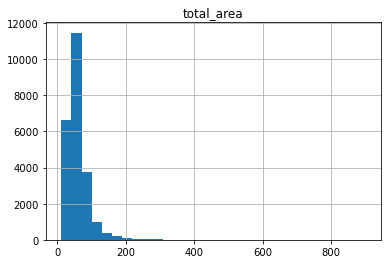

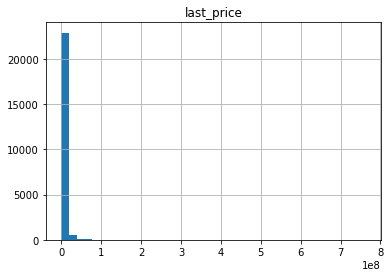

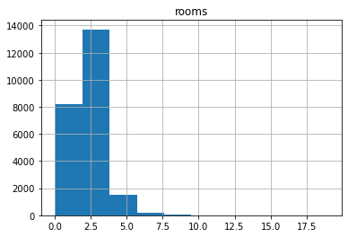

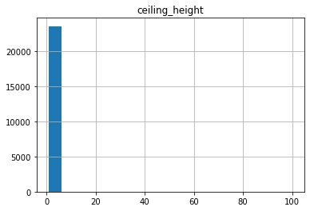

```python
def graph_for_each_param(df):
    list_of_params = [('total_area',30),('last_price',40),('rooms',10),('ceiling_height',20)]
    for (param,bins) in list_of_params:
        df.hist(param,bins=bins)
        plt.show()

graph_for_each_param(data)
```

### Вывод

```python
data['last_price'].min()
#но тут мы видим,что самая дешевая квартира стоила 12190,хм надо бы потюнить корзины на графике или же все-таки мошенники
```

```
12190
```

```python
data['rooms'].min()
```

```
0
```

Опачки,а вот и джекпот,не может быть таких квартир,в которых 0 комнат. Ошибки предобработки ...  
Сейчас исправим

```python
data = data[data['rooms'] > 0]
```

```python
data['rooms'].min()
```

```
1
```

#### Исследуем время продажи квартиры

```
(96.0, 181.4051562654047)
```

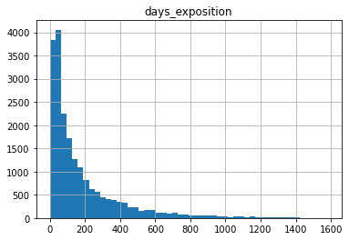

```python
# построим гистограмму по данным о том,какое время каждая квартира продавалась
data.hist('days_exposition',bins=50)

#найдем медиану и среднее
data['days_exposition'].median(), data['days_exposition'].mean()
```

#### Вывод

В среднем,при хороших условиях,квартира продается от 2 до 5 месяцев,но и посмотрев на грфик делаем вывод о том,что очень мало продаж которые идут больше полутора лет - это уже слишком долго,а что касается слишком которотких продаж,то это те продажи,которые шли менее чем 20-25 дней.

#### Удаление выбивающихся значений

```python
# Удалим те квартиры,которые продавались больше полутора лет
data = data[data['days_exposition'] < 540]
```

```
array([[<matplotlib.axes._subplots.AxesSubplot object at 0x11bbda2e0>]],
      dtype=object)
```

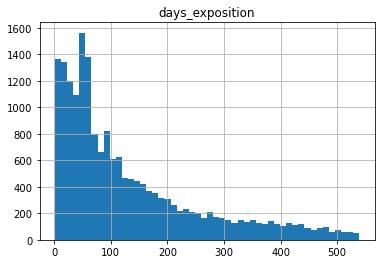

```python
data.hist('days_exposition',bins=50)
```

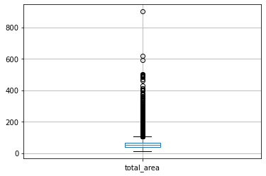

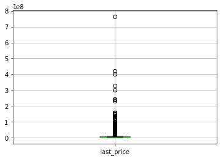

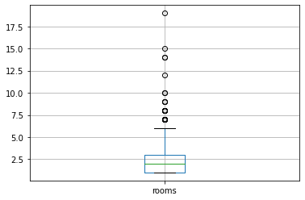

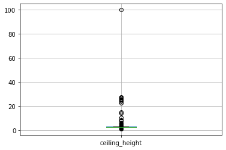

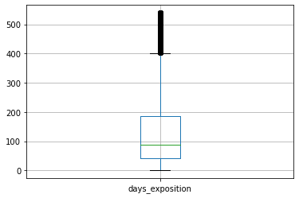

```python
list_of_params = ['total_area','last_price','rooms','ceiling_height','days_exposition']
for param in list_of_params:
    data.boxplot(param)
    plt.show()
```

#### Удалим из датасета выбросы

```python
data = data[(data['total_area'] <= 650) & (data['last_price'] <= 5e7) & (data['ceiling_height'] < 20)]
data.head()
```

|  | last_price | total_area | first_day_exposition | rooms | ceiling_height | floors_total | living_area | floor | kitchen_area | locality_name | ... | days_exposition | flat_class | sell_duration | cost_per_meter | exposition_weekday | exposition_month | exposition_year | flat_floor_position | living_to_total_area | kitchen_to_total_area |
| --- | --- | --- | --- | --- | --- | --- | --- | --- | --- | --- | --- | --- | --- | --- | --- | --- | --- | --- | --- | --- | --- |
| 1 | 3350000 | 40.40 | 2018-12-04 | 1 | 2.782385 | 11 | 18.60 | 1 | 11.00 | посёлок шушары | ... | 81.0 | средняя | средне | 82920 | 1 | 12 | 2018 | первый | 0.460396 | 0.272277 |
| 4 | 10000000 | 100.00 | 2018-06-19 | 2 | 3.030000 | 14 | 32.00 | 13 | 41.00 | санкт-петербург | ... | 121.0 | большая | средне | 100000 | 1 | 6 | 2018 | другой | 0.320000 | 0.410000 |
| 5 | 2890000 | 30.40 | 2018-09-10 | 1 | 2.640258 | 12 | 14.40 | 5 | 9.10 | городской посёлок янино-1 | ... | 55.0 | средняя | средне | 95065 | 0 | 9 | 2018 | другой | 0.473684 | 0.299342 |
| 6 | 3700000 | 37.30 | 2017-11-02 | 1 | 2.709259 | 26 | 10.60 | 6 | 14.40 | посёлок парголово | ... | 155.0 | средняя | средне | 99195 | 3 | 11 | 2017 | другой | 0.284182 | 0.386059 |
| 8 | 2900000 | 33.16 | 2018-05-23 | 1 | 2.675556 | 27 | 15.43 | 26 | 8.81 | посёлок мурино | ... | 189.0 | средняя | средне | 87454 | 2 | 5 | 2018 | другой | 0.465320 | 0.265682 |

5 rows × 21 columns

```python
data.info()
```

```
<class 'pandas.core.frame.DataFrame'>
Int64Index: 18662 entries, 1 to 23695
Data columns (total 21 columns):
 #   Column                 Non-Null Count  Dtype
---  ------                 --------------  -----
 0   last_price             18662 non-null  int64
 1   total_area             18662 non-null  float64
 2   first_day_exposition   18662 non-null  datetime64[ns]
 3   rooms                  18662 non-null  int64
 4   ceiling_height         18662 non-null  float64
 5   floors_total           18662 non-null  int64
 6   living_area            18662 non-null  float64
 7   floor                  18662 non-null  int64
 8   kitchen_area           18662 non-null  float64
 9   locality_name          18662 non-null  object
 10  cityCenters_nearest    18662 non-null  float64
 11  days_exposition        18662 non-null  float64
 12  flat_class             18662 non-null  object
 13  sell_duration          18662 non-null  object
 14  cost_per_meter         18662 non-null  int64
 15  exposition_weekday     18662 non-null  int64
 16  exposition_month       18662 non-null  int64
 17  exposition_year        18662 non-null  int64
 18  flat_floor_position    18662 non-null  object
 19  living_to_total_area   18662 non-null  float64
 20  kitchen_to_total_area  18662 non-null  float64
dtypes: datetime64[ns](1), float64(8), int64(8), object(4)
memory usage: 3.1+ MB
```

#### Выводим зависимости цены от различных параметров

```python
#соберем необходимые параметры в отдельный фрейм и построим таблицу с коэффицентом корреляции Пирсона
corr_data = data[['last_price','total_area','rooms','cityCenters_nearest','flat_floor_position','exposition_weekday','exposition_month','exposition_year']]
corr_data.corr()
```

|  | last_price | total_area | rooms | cityCenters_nearest | exposition_weekday | exposition_month | exposition_year |
| --- | --- | --- | --- | --- | --- | --- | --- |
| last_price | 1.000000 | 0.776808 | 0.504529 | -0.294127 | -0.001502 | 0.002391 | -0.036265 |
| total_area | 0.776808 | 1.000000 | 0.776984 | -0.197727 | 0.000365 | 0.003287 | -0.070572 |
| rooms | 0.504529 | 0.776984 | 1.000000 | -0.149428 | 0.001035 | 0.003104 | -0.062823 |
| cityCenters_nearest | -0.294127 | -0.197727 | -0.149428 | 1.000000 | 0.004144 | -0.011071 | 0.012651 |
| exposition_weekday | -0.001502 | 0.000365 | 0.001035 | 0.004144 | 1.000000 | 0.009471 | -0.001781 |
| exposition_month | 0.002391 | 0.003287 | 0.003104 | -0.011071 | 0.009471 | 1.000000 | -0.218146 |
| exposition_year | -0.036265 | -0.070572 | -0.062823 | 0.012651 | -0.001781 | -0.218146 | 1.000000 |

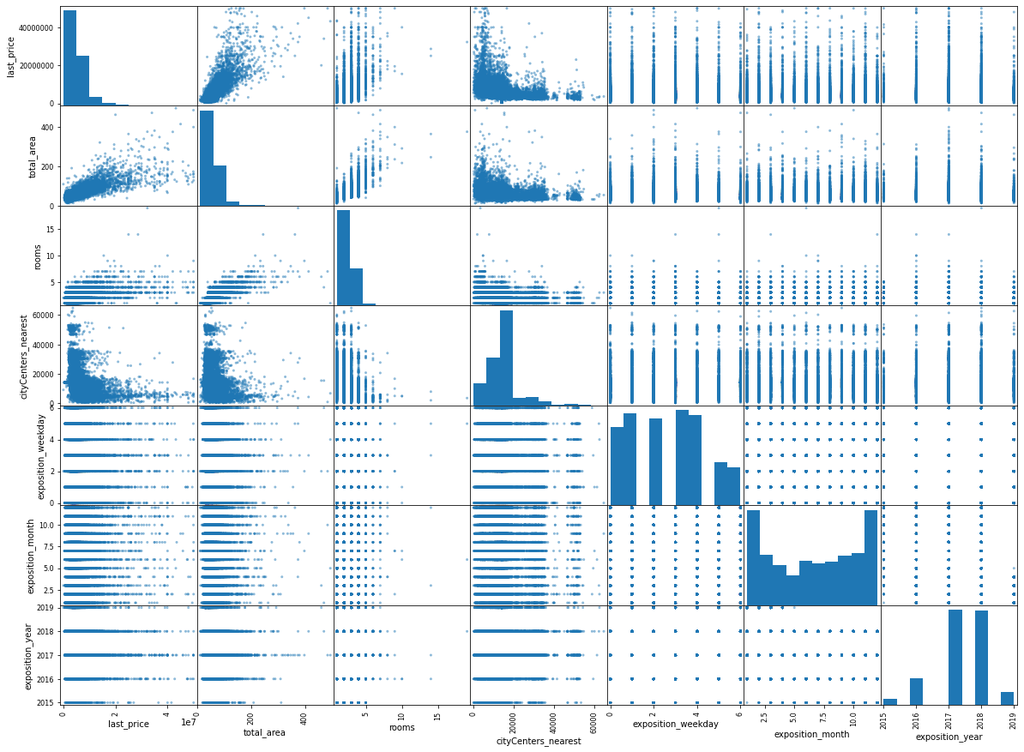

```python
#и тут сразу же матрицу построиим
pd.plotting.scatter_matrix(corr_data,figsize=(20,15))
print()
```

#### Вывод

Взглянув на корреляционную таблицу и матрицу распределения,мы можем сделать вывод о том,что цена квартиры в первую очередь зависит от площади,количества комнат и расстояние до центра города.Что касается остальных параметров - их коэффицент практически везде стремится к 0 => эти параметры не влияют на цену.

Разберемся с площадью,количеством комнат и расстоянием до центра.Итак самый большой и положительный коэффицент у площади => прямопропорциональная зависимость: чем больше площадь,тем больше цена.Что же касается количества комнат,то здесь коэффицент чуть меньше,чем у площади,но тоже достаточно весомый.И так как он тоже положительный,то зависимость такая же как с площадью.А вот с расстоянием все интереснее:коэффицент корреляции отрицательный => зависимость обратная,чем дальше от центра - тем ниже цена.

```python
top_ten = data.pivot_table(index='locality_name',values='cost_per_meter',aggfunc='mean').sort_values(by='cost_per_meter',ascending=False).head(10)
top_ten
```

| locality_name | cost_per_meter |
| --- | --- |
| посёлок лисий нос | 168706.000000 |
| зеленогорск | 111332.047619 |
| санкт-петербург | 109404.098036 |
| пушкин | 101751.510714 |
| сестрорецк | 101643.728477 |
| кудрово | 98193.328467 |
| посёлок левашово | 96997.000000 |
| деревня мистолово | 96156.777778 |
| деревня кудрово | 92416.917647 |
| посёлок стрельна | 89664.750000 |

#### Вывод

Как бы странно это не звучало,но самый дешевый квадратный метр из самых дорогих квадратных метров продавался в поселке Стрельна,а самый дорогой из самых дорогих - в поселке Лисий нос

#### Изучаем квартиры конкретно в СПБ и определяем границы центра

```python
#квартиры конкретно в спб
spb_flats = pd.DataFrame(data.query('locality_name == "санкт-петербург"'))
spb_flats.head()
```

|  | last_price | total_area | first_day_exposition | rooms | ceiling_height | floors_total | living_area | floor | kitchen_area | locality_name | ... | days_exposition | flat_class | sell_duration | cost_per_meter | exposition_weekday | exposition_month | exposition_year | flat_floor_position | living_to_total_area | kitchen_to_total_area |
| --- | --- | --- | --- | --- | --- | --- | --- | --- | --- | --- | --- | --- | --- | --- | --- | --- | --- | --- | --- | --- | --- |
| 4 | 10000000 | 100.0 | 2018-06-19 | 2 | 3.030000 | 14 | 32.0 | 13 | 41.0 | санкт-петербург | ... | 121.0 | большая | средне | 100000 | 1 | 6 | 2018 | другой | 0.320000 | 0.410000 |
| 9 | 5400000 | 61.0 | 2017-02-26 | 3 | 2.500000 | 9 | 43.6 | 7 | 6.5 | санкт-петербург | ... | 289.0 | средняя | долго | 88524 | 6 | 2 | 2017 | другой | 0.714754 | 0.106557 |
| 10 | 5050000 | 39.6 | 2017-11-16 | 1 | 2.670000 | 12 | 20.3 | 3 | 8.5 | санкт-петербург | ... | 137.0 | средняя | средне | 127525 | 3 | 11 | 2017 | другой | 0.512626 | 0.214646 |
| 15 | 4650000 | 39.0 | 2017-11-18 | 1 | 2.731545 | 14 | 20.5 | 5 | 7.6 | санкт-петербург | ... | 19.0 | средняя | быстро | 119230 | 5 | 11 | 2017 | другой | 0.525641 | 0.194872 |
| 16 | 6700000 | 82.0 | 2017-11-23 | 3 | 3.050000 | 5 | 55.6 | 1 | 9.0 | санкт-петербург | ... | 397.0 | средняя | долго | 81707 | 3 | 11 | 2017 | первый | 0.678049 | 0.109756 |

5 rows × 21 columns

```python
# посчитаем расстояние до центра в километрах
spb_flats['km_center_distance'] = (spb_flats.loc[:,['cityCenters_nearest']] / 1000).astype('int')
```

```python
spb_flats.head()
```

|  | last_price | total_area | first_day_exposition | rooms | ceiling_height | floors_total | living_area | floor | kitchen_area | locality_name | ... | flat_class | sell_duration | cost_per_meter | exposition_weekday | exposition_month | exposition_year | flat_floor_position | living_to_total_area | kitchen_to_total_area | km_center_distance |
| --- | --- | --- | --- | --- | --- | --- | --- | --- | --- | --- | --- | --- | --- | --- | --- | --- | --- | --- | --- | --- | --- |
| 4 | 10000000 | 100.0 | 2018-06-19 | 2 | 3.030000 | 14 | 32.0 | 13 | 41.0 | санкт-петербург | ... | большая | средне | 100000 | 1 | 6 | 2018 | другой | 0.320000 | 0.410000 | 8 |
| 9 | 5400000 | 61.0 | 2017-02-26 | 3 | 2.500000 | 9 | 43.6 | 7 | 6.5 | санкт-петербург | ... | средняя | долго | 88524 | 6 | 2 | 2017 | другой | 0.714754 | 0.106557 | 15 |
| 10 | 5050000 | 39.6 | 2017-11-16 | 1 | 2.670000 | 12 | 20.3 | 3 | 8.5 | санкт-петербург | ... | средняя | средне | 127525 | 3 | 11 | 2017 | другой | 0.512626 | 0.214646 | 13 |
| 15 | 4650000 | 39.0 | 2017-11-18 | 1 | 2.731545 | 14 | 20.5 | 5 | 7.6 | санкт-петербург | ... | средняя | быстро | 119230 | 5 | 11 | 2017 | другой | 0.525641 | 0.194872 | 14 |
| 16 | 6700000 | 82.0 | 2017-11-23 | 3 | 3.050000 | 5 | 55.6 | 1 | 9.0 | санкт-петербург | ... | средняя | долго | 81707 | 3 | 11 | 2017 | первый | 0.678049 | 0.109756 | 10 |

5 rows × 22 columns

```python
# отсортируем наши данные
spb_flats.sort_values(by='km_center_distance',inplace=True)
```

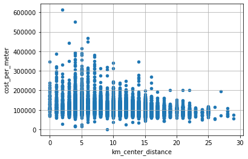

```python
spb_flats.plot(x='km_center_distance',y='cost_per_meter',grid=True,kind='scatter')
```

Мы наблюдаем резкие изменения на графике,когда дистанция до центра примерно равна 5 км => выдвигаем предположение,что квартиры находящиеся в радиусе 5 км находятся в центре города.

#### Изучим квартиры в центре

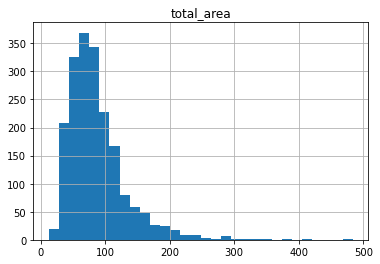

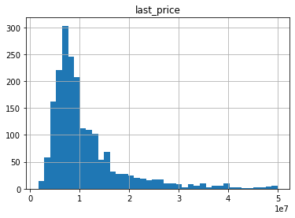

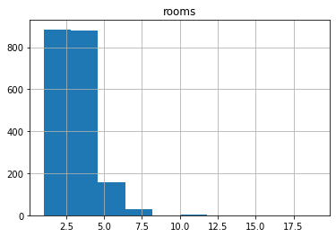

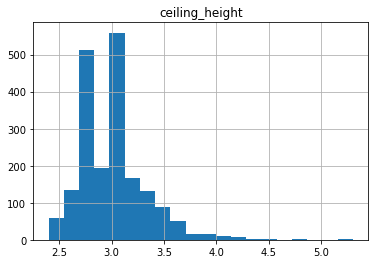

```python
#выберем все квартиры в центре петрбурга
spb_center_flats = spb_flats[spb_flats['km_center_distance'] <= 5]

# вызовем уже написанную функцию для отрисовки гистограмм по необходимым параметрам
graph_for_each_param(spb_center_flats)
```

```python
center_corr_data = spb_center_flats[['last_price','total_area','rooms','cityCenters_nearest','flat_floor_position','exposition_weekday','exposition_month','exposition_year']]
center_corr_data.corr()
```

|  | last_price | total_area | rooms | cityCenters_nearest | exposition_weekday | exposition_month | exposition_year |
| --- | --- | --- | --- | --- | --- | --- | --- |
| last_price | 1.000000 | 0.716676 | 0.459708 | -0.009998 | -0.022162 | -0.019651 | -0.006537 |
| total_area | 0.716676 | 1.000000 | 0.786678 | -0.066956 | -0.002384 | -0.010375 | -0.068599 |
| rooms | 0.459708 | 0.786678 | 1.000000 | -0.107306 | 0.012557 | -0.005376 | -0.055920 |
| cityCenters_nearest | -0.009998 | -0.066956 | -0.107306 | 1.000000 | -0.055101 | -0.000381 | 0.022873 |
| exposition_weekday | -0.022162 | -0.002384 | 0.012557 | -0.055101 | 1.000000 | 0.052375 | -0.013609 |
| exposition_month | -0.019651 | -0.010375 | -0.005376 | -0.000381 | 0.052375 | 1.000000 | -0.203222 |
| exposition_year | -0.006537 | -0.068599 | -0.055920 | 0.022873 | -0.013609 | -0.203222 | 1.000000 |

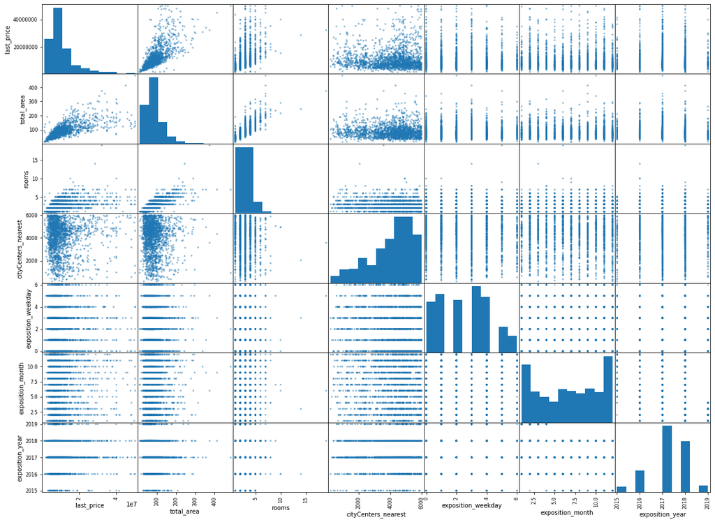

```python
pd.plotting.scatter_matrix(center_corr_data,figsize=(20,15))
print()
```

#### Вывод

В данном случае мы замечаем то,что по-прежнему площадь очень хорошо коррелирует с ценой квартиры,что касается количества комнат,то судя по всему людям,живущем в центре не так сильно важно количество комнат,нежели людям,которые не живут в центре.Коэффицент корреляции удаленности от центра практически нулевой,потому что все данные квартиры находятся в центре.

### Шаг 5. Линейная регрессия

#### Разделим данные на обучающие и тестовые

```python
X = pd.DataFrame(data[['total_area','rooms','ceiling_height','floors_total','floor']])
X['constant'] = 1
y = data['last_price']

""" Здесь мы перевели все из пандаса в нампай """
X = X.values
y = y.values
```

```python
X_train, X_test, y_train, y_test =  train_test_split(X, y, test_size = 0.2)
```

В задаче регрессии как функцию потерь будем использовать $MSE = \frac{1}{n} \sum_{i=1}^{n} (pred_i - y_i)^2$,  
где $n$ - количество объектов в выборке, $pred_i$ - предсказание на i-м объекте, $y_i$ - истинный ответ на i-м объекте.

### Тут мы будем объявлять линейную регрессию

```python
linreg = LinearRegression().fit(X_train,y_train) #Обучаем ее прямо тут
predicts = linreg.predict(X_test) #Делаем предикт на тестовой выборке
```

### А здесь мы будем оценивать нашу модель с помощью MSE

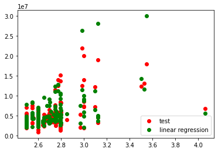

```python
plt.scatter(X_test[:150, 2], y_test[:150], c='r', label='test')
plt.scatter(X_test[:150, 2], predicts[:150], c='g', label='linear regression')
plt.legend(loc="lower right")
```

Как мы видим по графику,предсказания нашей модели на тестовой выборке выглядят очень даже неплохо,но чтобы в это м удостовериться - посчитаем MSE на обучающей выборке и на тестовой и сравним.

```python
print("Train MSE error:", mean_squared_error(y_train, linreg.predict(X_train)))
print("Test MSE error:", mean_squared_error(y_test, predicts))
```

```
Train MSE error: 7553885166676.051
Test MSE error: 6202146191050.428
```

Как мы видим - ошибка на тестовой выборке ниже,поэтому мы делаем вывод о том,что наша модель обучилась довольно хорошо,как раз график - тому подтверждение.

### А теперь попробуем получить предсказание по квартире,которую хотел продавать мой дядя.

```python
uncle_pred = int(linreg.predict(np.array([72,3,3,4,4,1]).reshape(1, -1))[0])
print(f'Примерная данной квартиры:{uncle_pred}₽')
```

```
Примерная данной квартиры:7048486₽
```

А продавал он ее за **7.000.000₽**,так что делаем вывод о том,что линрег обучен очень хорошо и можно его использовать в предсказании стоимости квартиры.